# League of Legends Data Analysis Tutorial

```
by Gerald Liu and On Choi
 - CMSC 320 Fall 2019
```

[figure not shown]

## 1. Introduction

League of Legends (LoL) is a MOBA (Multiplayer Online Battle Arena) published by Riot Games in 2009 and is the [most popular online PC game](https://newzoo.com/insights/rankings/top-20-core-pc-games/) as of November 2019. The competitive scene or e-sports has been popular among players and the most recent international tornament had an estimated 99.6 million viewers and had a $2.5 million prize pool for over 100 teams accross 13 regions around the world [(source)](https://www.businessinsider.com/league-of-legends-world-championship-winner-funplus-phoenix-photos-2019-11). There is an estimated >100 million matches of league played per day with 8 million concurrent players at any given time as of 2017 and that number as only gone up. As a result, LoL has generated a plethora of data over the years and much can be learned from any perspective and purpose.

In our tutorial, we will looking at match and player data for the North American Server for the latest season as of December 2019. We will crawl the league API to gather and tidy up useful data to see if we can find any patterns. This will involve an sample exploratory data analysis (EDA) to find any useful patterns such as predicting win rate and use machine learning to find the most important factor in winning a game. We hope that this tutorial can provide insight in how the Riot API works and to encourage new and experienced players to see how interconnected the field of data science and video games can really be.

**1.1 [How do you play League of Legends?](https://www.youtube.com/watch?v=BGtROJeMPeE) How does one win?**

[figure not shown]

```
                                                                                        -Map of League of Legends
```

- Traditional Competitive League of Legends (LoL) is played by 10 players with 2 sides (Blue and Red side) having 5 players each.
- The objective is to destroy the opposing team's Nexus or base.
- Each player chooses a "champion" (playable character) before the game starts. This champion is chosen in mind to work with your team and your own strengths. At the time of this tutorial, there are [146 playable champions](https://na.leagueoflegends.com/en/game-info/champions/).
- Each "champion" has a unique set of skills that can range from dealing tons of damage, healing, or applying "crowd control" buffs/debuffs (CC) such as stuns, binds, and freezes.
- Furthermore, each champion fall under a list of categories or classes. Some champions are exclusivly ranged marksman fighters, some are melee based and prefer to fight on the front lines, and some are magic based mages that cast spells as their primary way of damage.
- The champion classes are listed [here](https://na.leagueoflegends.com/en/news/game-updates/gameplay/taking-another-look-subclasses) and include Tanks, Fighters, Slayers, Mages, Controllers, and Marksmen.
- To defeat the enemy base or Nexus, you must destroy at every turret in at least 1 lane (Top, Mid, Bottom). Then, you will need to destroy at least 1 inhibitor and both the Nexus turrets to finally break the enemy nexus open.
- This process can take 15 minutes up to over an hour depending on how back and forth the game is going.
- At 1 minute 5 seconds, waves of "minions" will spawn every 30 seconds for each team and for each lane. These minions are controlled by the game's AI and have only a basic attacking skill (melee, caster, seige) that help their team's players take towers and progress the game. Once an inhibitor is destroyed for a certain lane, "super" minions start to spawn that make them very strong and help push lanes even more.
- Players will be given gold as the game progresses (passive income) and also awarded gold for killing enemy "minions" (also called creep), enemy champions (players), or capturing certain game objectives (towers, baron, first blood, ect).
- This gold can be used to buy items in the shop to obtain powerful weapons and bonuses that can make your champion extremely strong.
- Players also get experience and level up from being in the area of enemy minion, player, or objective deaths. Each level (max 18) gives you more base stats and a skill point which can be used to level up your skills (usually max level 5, max level 3 for ultimate). These skill upgrades are cruicial to winning the game as they provide more damage, longer CC, more healing, ect.
- Most champions (some are unique) have an ultimate ability (unlocked at level 6) that have longer cooldowns but can significantly sway the course of a match.

We've only listed the basics and there's so much more to learn about the game, its community, and the compeitive scene. You can learn more at https://na.leagueoflegends.com/en/.

## 2. Required Libraries/Resources

- All libraries and code will be imported/written with python 3 in mind. If you have python 2, use the future library or upgrade :D
- To scrape League of Legends data, we need requets, beautifulsoup4, and json
- Pandas and Numpy will be used to transform and tidy our dataset
- matplotlib and seaborn for data visualization
- sklearn for predictions and machine learning
- urllib for converting characters in string into escaped characters (for hitting the API)
- time to sleep for rate limit
- random to randomly crawl riot api
- os to read in generated data sets
- We need an API key to access the Riot API. We will load it from a hidden file called 'api_key.json'. Generate yours at https://developer.riotgames.com/.

```python
# Imports
import pandas as pd
import numpy as np
from sklearn import linear_model
from sklearn.ensemble import RandomForestClassifier
from sklearn.model_selection import train_test_split, cross_val_score
from sklearn.neighbors import KNeighborsClassifier
from sklearn.metrics import confusion_matrix, classification_report
import matplotlib.pyplot as plt
import seaborn as sns
import requests
import json
from bs4 import BeautifulSoup
import urllib
import time
import random
import os.path
from os import path
# Ignore warnings
import warnings
warnings.filterwarnings('ignore')

# API Key obtained from Riot Developer Portal (unique for account expires every 24 hours)
# However, you can apply for an permanent API key at https://developer.riotgames.com/app-type
API_KEY = 'XXXXX-XXXXXXXX-XXXX-XXXX-XXXX-XXXXXXXXXXXX'
# We have our API key loaded from a json file (can also be stored as an evironment variable if you would like)
with open('api_key.json') as f:
    API_KEY = json.load(f)['API_KEY']

# These are our parameters we will be working with for match data
PARAMS = ['gameId', 'summonerId', 'seasonId', 'gameVersion', 'gameMode', 'gameType', 'queueId', 'teamId', 'gameDuration',\
          'win', 'participantId', 'role', 'tier', 'rank','kills', 'deaths', 'assists','championId', 'minionsKilled',\
          'champLevel', 'wardsPlaced', 'goldEarned', 'goldSpent', 'visionScore', 'totalDamageDealt', 'largestMultiKill',\
          'teamFirstBlood', 'teamFirstTowerKill', 'teamFirstInhibitor', 'teamFirstBaron', 'teamFirstDragon',\
          'teamFirstRiftHerald', 'towerKills', 'inhibitorKills', 'baronKills', 'dragonKills', 'riftHeraldKills']

# Set random seed
random.seed(1)
```

# 3. Data Collection (API Crawling)

To gather match data, Riot provides an [API](https://developer.riotgames.com/apis) that has data for matches, summoners (players), champions (playable characters), ect.

## Using Riot's API

- Riot has a [developer portal](https://developer.riotgames.com/) which you will need a Riot [account](https://developer.riotgames.com/login).
- You will need an API Key and generate it daily or [apply for a product API key](https://developer.riotgames.com/app-type) which will persist.
- Documentation can be found at https://developer.riotgames.com/apis
- Riot has rate limits of 20 requests/second and 100 requests/2 min. Data generation will take a while to generate enough data to learn on. Therefore, we will export data into a file to pull from while generating data as often as we can.
- Example for calling summoner (player) information for current API version (v4):
  - https://na1.api.riotgames.com/lol/summoner/v4/summoners/by-name/SUMMONER_NAME?api_key= + API_KEY

### "Random" Game Data

- Riot only provides game data from a given gameID which cannot be randomly gotten. Therefore, we need to start from a seeded playerID and crawl through that players' teammates and opponents games to generate enough data to preform data analysis.
- Our set seed will be on one of our summoner IDs "50g Tibbers" on the North American server.

  **Scrapping Methods:**

tidy_game_data(match, region, key)

```
- Given a league of legends match, transform into a pandas DataFrame and return
- 10 rows = 10 players and their stats (see PARAMS global for column names)
```

```python
def tidy_game_data(match, region, key):
    players = match['participants']
    player_rows = []
    df = pd.DataFrame(columns=PARAMS)
    for n in range(len(players)):
        player = players[n]
        summonerId = match['participantIdentities'][n]['player']['summonerId']
        stats = player['stats']
        teamId = player['teamId']
        wardsPlaced = 0
        status_200 = False

        # Get player's league rank
        while not status_200:
            league = requests.get("https://{}.api.riotgames.com/lol/league/v4/entries/by-summoner/{}?api_key={}".format(region, summonerId, key))
            time.sleep(1.2)
            if league.status_code == 200:
                status_200 = True
                league = league.json()
            else:
                print("Error {} restarting query on {}".format(league.status_code, summonerId))

        tier = 'UNRANKED'
        rank = 'N/A'
        if league:
            tier = league[0]['tier']
            rank = league[0]['rank']
        log = open(r"log.txt", "a+")
        log.write("Player {}, summonerId: {}, Tier: {}, Rank: {}\n".format(n+1, summonerId, tier, rank))
        log.close()
        # Sometimes no wards are placed
        if 'wardsPlaced' in stats:
            wardsPlaced = stats['wardsPlaced']
        row = {
            'gameId': match['gameId'],
            'summonerId': summonerId,
            'seasonId': match['seasonId'],
            'gameVersion': match['gameVersion'],
            'gameMode': match['gameMode'],
            'gameType': match['gameType'],
            'queueId': match['queueId'],
            'teamId': teamId,
            'gameDuration': match['gameDuration'],
            'win': stats['win'],
            'participantId': player['participantId'],
            'role': player['timeline']['lane'],
            'tier': tier,
            'rank': rank,
            'kills': stats['kills'],
            'deaths': stats['deaths'],
            'assists': stats['assists'],
            'championId': player['championId'],
            'minionsKilled': stats['totalMinionsKilled'],
            'champLevel': stats['champLevel'],
            'wardsPlaced': wardsPlaced,
            'goldEarned': stats['goldEarned'],
            'goldSpent': stats['goldSpent'],
            'visionScore': stats['visionScore'],
            'totalDamageDealt': stats['totalDamageDealt'],
            'largestMultiKill': stats['largestMultiKill'],
        }
        for team in match['teams']:
            if team['teamId'] == teamId:
                row['teamFirstBlood'] = team['firstBlood']
                row['teamFirstTowerKill'] = team['firstTower']
                row['teamFirstInhibitor'] = team['firstInhibitor']
                row['teamFirstBaron'] = team['firstBaron']
                row['teamFirstDragon'] = team['firstDragon']
                row['teamFirstRiftHerald'] = team['firstRiftHerald']
                row['towerKills'] = team['towerKills']
                row['inhibitorKills'] = team['inhibitorKills']
                row['baronKills'] = team['baronKills']
                row['dragonKills'] = team['dragonKills']
                row['riftHeraldKills'] = team['riftHeraldKills']
                # bans added here
        df = df.append(row, ignore_index=True)
    return df
```

get_match_history(region, accountId, key)

```
- Given an accountId, return match history of account
```

```python
def get_match_history(region, accountId, key):
    log = open(r"log.txt", "a+")
    log.write("Attempting to get match history for accountId: {}\n".format(accountId))
    log.close()
    while True:
        # https://developer.riotgames.com/apis#match-v4/GET_getMatchlist
        match_history = requests.get("https://{}.api.riotgames.com/lol/match/v4/matchlists/by-account/{}?api_key={}".format(region, accountId, key))
        # Sleep to account for rate limit. 100 requests per 2 minutes
        time.sleep(1.2)
        if match_history.status_code == 200:
            return match_history.json()
```

get_match_info(region, matchId, key)

```
- Given matchId, return match information from API
```

```python
def get_match_info(region, matchId, key):
    # https://developer.riotgames.com/apis#match-v4/GET_getMatch
    while True:
        match = requests.get("https://{}.api.riotgames.com/lol/match/v4/matches/{}?api_key={}".format(region, matchId, key))
        # Sleep to account for rate limit. 100 requests per 2 minutes
        time.sleep(1.2)
        if match.status_code == 200:
            return match.json()
```

transform_match(match, visited_players, region, key, seed=None)

```
- From a match, select the next accountId to continue API crawl
```

```python
def transform_match(match, visited_players, region, key, seed=None):
    # Players should have length 10 (5 players vs. 5 players)
    players = match['participantIdentities']
    player_counter = 0
    # Grab a random player from match (ally or enemy team)
    random_order = list(range(len(players)))
    if seed:
        random.seed(seed)
    # Random order is seeded above (to replicate results)
    random.shuffle(random_order)
    for n in random_order:
        chosen_one = players[n]['player']['currentAccountId']
        # Ensure that player has not been seen before
        if chosen_one not in visited_players:
            visited_players.add(chosen_one)
            return tidy_game_data(match, region, key), chosen_one, visited_players
        player_counter += 1
        # If all players have been seen...
        if player_counter == len(players):
            raise Exception("All players seen (unlikely) Should choose a new summoner to crawl... but implementation later")
```

get_most_recent_valid(match_history, visited_matches, correct_queues, season, visited_players)

```
- Recursively find the most recent valid match from match history
- If invalid history found, will continue to crawl on a randomly seen summoner
```

```python
def get_most_recent_valid(match_history, visited_matches, correct_queues, season, visited_players):
    for match in match_history['matches']:
        if match['season'] == season and match['gameId'] not in visited_matches and match['queue'] in correct_queues:
            visited_matches.add(match['gameId'])
            return match, visited_matches\
    # If seed summoner has no valid matches in history
    if len(visited_matches) == 0:
        raise Exception("Seed summoner has no valid 5v5 PVP matches in their history.")
    # If invalid match history
    random_summoner = random.choice(tuple(visited_players))
    log = open(r"log.txt", "a+")
    log.write("Match history is bad. Chosing new random summoner {} to keep crawling on.\n".format(random_summoner))
    log.close()
    # Recurse until valid match is found
    match_history = get_match_history(region, random_summoner, key)['matches']
    get_most_recent_valid(match_history, visited_matches, correct_queues, season, visited_players)
```

get_random_matches(num_matches, seed_summoner, key, region, season, sleep_delay) Main scrapping function

```
Will output matchData.csv with match data and log.txt for any troubleshooting
- Will return pandas DataFrame with data on a given # of matches (int: num_matches=100)
- Needs a seed summoner to start API Crawling (string: seed_summoner)
- Needs your riot API key to pull requests with (string: key=API_KEY)
- Need a valid league of legends region (string: region='na1')
- Needs a valid season # to pull correct matches from (int: season=13)
- Between matches, function will sleep to account for API latency (float: sleep_delay=0.2)
```

```python
# Grab random PVP matches based on seed_summoner exlusive to region/season but any rank and any player level.
def get_random_matches(num_matches=100, seed_summoner="50g Tibbers", key=API_KEY, region="na1", season=13, sleep_delay=0.2):
    start_time = time.time()
    # Clear log file
    open(r"log.txt", 'w').close()
    # Estimated Time based on rate limit
    seconds = (num_matches * 1.2) * 11 + num_matches * sleep_delay
    print("Getting {} matches. This will take minimum {} seconds to complete. \n".format(num_matches, seconds))

    # Get seed summoner accountId
    seed_request = requests.get("https://{}.api.riotgames.com/lol/summoner/v4/summoners/by-name/{}?api_key={}".format(region, seed_summoner, API_KEY))
    # Sleep to account for rate limit. 100 requests per 2 minutes
    time.sleep(1.2)
    # If status code 404, raise exception
    if seed_request.status_code == 404:
        raise Exception("Error Code 404. Invalid seed_summoner, region, or API key (ensure that it has not expired).")
    seed_json = seed_request.json()
    accountId = seed_json['accountId']
    summonerIds = [] #seed_json['id']
    print("Seed Summoner = {}. accountId = {}".format(seed_summoner, accountId))

    # Keep visited set to ensure no duplicates
    visited_players = set()
    visited_matches = set()

    # Add seed_summoner accountId to visited (we start here and crawl)
    visited_players.add(accountId)

    # Only select 5v5 PVP games (blind = 430, draft = 400, ranked = 420)
    # All queueId constants found here: http://static.developer.riotgames.com/docs/lol/queues.json
    correct_queues = set([430, 400, 420])

    # Match DataFrame that holds all match data and will be returned
    matches = pd.DataFrame(columns=PARAMS)

    for m in range(num_matches):

        # Grab account's match history from API
        match_history = get_match_history(region, accountId, key)

        # Get most recent valid game from season parameter. Then grab gameId to get match info.
        most_recent, visited_matches = get_most_recent_valid(match_history, visited_matches, correct_queues, season, visited_players)
        gameId = most_recent['gameId']

        # Grab match info from API
        match = get_match_info(region, gameId, key)
        log = open(r"log.txt", "a+")
        log.write("Found match #{}: {} for {}\n".format(m+1, gameId, accountId))
        log.close()
        # Transform match format into pandas DataFrame
        rows, accountId, visited_players = transform_match(match, visited_players, region, key)
        # Add to matches DataFrame
        matches = matches.append(rows)

        # Sleep for good measure (can be configured based on API latency)
        # Check here for riot api status: https://developer.riotgames.com/api-status/
        time.sleep(sleep_delay)

        # Now, we should have another accountId to work with
        # Continue loop until we have num_matches


    # Display runtime and return matches and summonerId list
    runtime = time.time() - start_time
    log = open(r"log.txt", "a+")
    log.write("Found {} matches in {} seconds\n".format(len(matches), runtime))
    print("Found {} matches in {} seconds".format(len(matches), runtime))
    log.close()
    return matches
```

```python
# Read in existing dataSet, or generate a new one with num_matches matches
if path.exists("matchData.csv"):
    matches = pd.read_csv(r'matchData.csv')
else:
    matches = get_random_matches(num_matches=10)
    matches.to_csv("matchData.csv", index=False)
matches.head()
```

|  | gameId | summonerId | seasonId | gameVersion | gameMode | gameType | queueId | teamId | gameDuration | win | ... | teamFirstTowerKill | teamFirstInhibitor | teamFirstBaron | teamFirstDragon | teamFirstRiftHerald | towerKills | inhibitorKills | baronKills | dragonKills | riftHeraldKills |
| --- | --- | --- | --- | --- | --- | --- | --- | --- | --- | --- | --- | --- | --- | --- | --- | --- | --- | --- | --- | --- | --- |
| 0 | 3235637352 | TphYrkzxVtPx0eZbqa4uvibv7khn2_6AwM_knTakx0uC | 13 | 9.24.300.6382 | CLASSIC | MATCHED_GAME | 430 | 100 | 239 | False | ... | False | False | False | False | False | 0 | 0 | 0 | 0 | 0 |
| 1 | 3235637352 | QqMC2vYG2No3qLZ_AKU0De0rAlqaZ9Wr6fDw9vZfWstPYLI | 13 | 9.24.300.6382 | CLASSIC | MATCHED_GAME | 430 | 100 | 239 | False | ... | False | False | False | False | False | 0 | 0 | 0 | 0 | 0 |
| 2 | 3235637352 | byS6yIEsPUbhyqP0LrxNAdC5DWrcPJmVPaOH0oQ_IKCRMKQ | 13 | 9.24.300.6382 | CLASSIC | MATCHED_GAME | 430 | 100 | 239 | False | ... | False | False | False | False | False | 0 | 0 | 0 | 0 | 0 |
| 3 | 3235637352 | IpnPo_LsY61sOsbPsRgVhwe1jmNdXF-m84rnkO3UwISwRY0 | 13 | 9.24.300.6382 | CLASSIC | MATCHED_GAME | 430 | 100 | 239 | False | ... | False | False | False | False | False | 0 | 0 | 0 | 0 | 0 |
| 4 | 3235637352 | FrOukjlGpmgEufAklfxp0TFQ4ogpqPB1Cf5p2pZ7TSfriqU | 13 | 9.24.300.6382 | CLASSIC | MATCHED_GAME | 430 | 100 | 239 | False | ... | False | False | False | False | False | 0 | 0 | 0 | 0 | 0 |

5 rows × 37 columns

```python
# Columns Present
matches.columns
```

```
Index(['gameId', 'summonerId', 'seasonId', 'gameVersion', 'gameMode',
       'gameType', 'queueId', 'teamId', 'gameDuration', 'win', 'participantId',
       'role', 'tier', 'rank', 'kills', 'deaths', 'assists', 'championId',
       'minionsKilled', 'champLevel', 'wardsPlaced', 'goldEarned', 'goldSpent',
       'visionScore', 'totalDamageDealt', 'largestMultiKill', 'teamFirstBlood',
       'teamFirstTowerKill', 'teamFirstInhibitor', 'teamFirstBaron',
       'teamFirstDragon', 'teamFirstRiftHerald', 'towerKills',
       'inhibitorKills', 'baronKills', 'dragonKills', 'riftHeraldKills'],
      dtype='object')
```

```python
# A preview of the numeric columns
matches[['gameId', 'teamId', 'win', 'participantId', 'championId', 'tier', 'rank', 'kills', 'deaths', 'assists', 'minionsKilled', 'goldEarned', 'teamFirstBlood']].head()
```

|  | gameId | teamId | win | participantId | championId | tier | rank | kills | deaths | assists | minionsKilled | goldEarned | teamFirstBlood |
| --- | --- | --- | --- | --- | --- | --- | --- | --- | --- | --- | --- | --- | --- |
| 0 | 3235637352 | 100 | False | 1 | 86 | UNRANKED | NaN | 0 | 0 | 0 | 13 | 1042 | False |
| 1 | 3235637352 | 100 | False | 2 | 28 | UNRANKED | NaN | 0 | 1 | 1 | 0 | 1286 | False |
| 2 | 3235637352 | 100 | False | 3 | 246 | GOLD | IV | 1 | 0 | 0 | 16 | 1411 | False |
| 3 | 3235637352 | 100 | False | 4 | 25 | PLATINUM | II | 0 | 0 | 0 | 10 | 1027 | False |
| 4 | 3235637352 | 100 | False | 5 | 523 | PLATINUM | III | 0 | 0 | 0 | 0 | 765 | False |

# 4. Exploratory Data Analysis

After getting the data from the API and cleaning it, we can analyze the data!

### Rank Distribution

Since we seeded off of a Platinum player, the rank of our player base might be based around this level (we cannot know for sure). We can analyze the rank distribution and compare it to [op.gg](https://na.op.gg/statistics/tier/) (a website that pulls millions of players' data and make analysis) to see how relevant our sample is. Then we can make adjustment to our prediction while keeping this bias in mind.

[figure not shown]

```
                    - Ranking Tiers:
                        - Iron, Bronze, Silver, Gold, Platium, Diamond, Masters, Grandmaster, Challenger
```

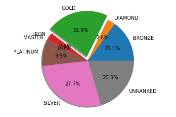

```python
rankgroup = matches.groupby('tier')
count = [rankgroup.get_group(r)['tier'].count() for r in rankgroup.groups]
rank = [r for r in rankgroup.groups]
explode = [0, 0, 0.1, 0, 0, 0, 0, 0]

fig1, ax1 = plt.subplots()
ax1.pie(count, explode=explode, labels=rank, autopct='%1.1f%%', shadow=True, startangle=0)
ax1.axis('equal')
plt.show()
```

Based on [op.gg](https://na.op.gg/statistics/tier/)'s statistic, below are their player rank distribution

- *Challenger* (0.02%)
- *Grandmaster* (0.04%)
- *Master* (0.09%)
- *Diamond* (3.48%)
- *Platinum* (14.5%)
- *Gold* (33.13%)
- *Silver* (32%)
- *Bronze* (14.84%)
- *Iron* (1.91%)

Our pool seems to have more silver ranks compared to gold ranks as opposed to op.gg's. However, out of the 10000 match data, we only have 2 sample data for master rank and nothing above that. We will have to remove masters, grandmasters, and challengers from our data set as there are too few of them.

### Rank In Terms of Vision Score

**What is warding? What is vision score?**

- As seen in the introduction, players play on a map labelled with different locations like top, bottom, middle, and jungle. In the jungle, there is a fog of war that covers more than half the map. Therefore it is very important to have vision at some parts of the map to gain knowledge on opponents' next movement.
- There is an item in the game that you can purchase called "ward". There are two types: the green ward and the pink ward. A green ward grants vision of an area within a small radius for up to 90 seconds. When it is placed, it gains invisibility after a couple seconds. An opponent can detect wards in an area using a sweeper item. A pink ward grants vision of an area within a small radius forever as long as the user of the ward has not placed another one elsewhere or the ward itself has not been destroyed. The pink ward does not go invisible and takes four hits to get destroyed.
- Warding is the act of purchasing and placing wards on the map. This is a very important aspect of the game as it allows the entire team to gain information about the other team's whereabout. The placement of the wards is important because it affects how much information you know.
- Vision score is a post-game statistic that Riot Game added to the post-game match analysis in 2017. It tells you how much vision a player has influenced the game. This is calculated mostly based on the lifetime of wards a player provided and the lifetime of wards a player denied in the game. The more complex and in-depth lifetime calculation can be found [here](https://leagueoflegends.fandom.com/wiki/Vision_score).

[figure not shown]

```
                                            - Invisible green ward vs. pink ward
```

```python
# Define the order of ranks
rank_order = ['UNRANKED', 'IRON', 'BRONZE', 'SILVER', 'GOLD', 'PLATINUM', 'DIAMOND', 'MASTER']
rank_dict = {r: None for r in rank_order}
for r in rankgroup.groups:
    rank_dict[r] = rankgroup.get_group(r)['visionScore'].mean()

rankgroup.describe()['visionScore']
```

| tier | count | mean | std | min | 25% | 50% | 75% | max |
| --- | --- | --- | --- | --- | --- | --- | --- | --- |
| BRONZE | 1511.0 | 17.795500 | 13.870207 | 0.0 | 9.00 | 15.0 | 22.00 | 157.0 |
| DIAMOND | 262.0 | 20.805344 | 17.074445 | 0.0 | 10.00 | 17.0 | 26.00 | 126.0 |
| GOLD | 2193.0 | 20.364797 | 14.675569 | 0.0 | 11.00 | 17.0 | 25.00 | 108.0 |
| IRON | 262.0 | 20.225191 | 13.853048 | 0.0 | 11.00 | 17.0 | 26.00 | 88.0 |
| MASTER | 2.0 | 13.500000 | 19.091883 | 0.0 | 6.75 | 13.5 | 20.25 | 27.0 |
| PLATINUM | 952.0 | 21.268908 | 15.437100 | 0.0 | 11.00 | 17.0 | 26.00 | 124.0 |
| SILVER | 2771.0 | 18.812342 | 13.771241 | 0.0 | 10.00 | 16.0 | 24.00 | 104.0 |
| UNRANKED | 2047.0 | 15.345383 | 13.271450 | 0.0 | 7.00 | 12.0 | 20.00 | 107.0 |

This table shows the mean of vision score among each rank group, as well as its percentile and other statistics.

```python
# Set color palette
colors = ["black", "brown", "tan", "grey", "marigold", "pale teal", "soft blue", "violet pink", "tomato red"]
new_palette = sns.xkcd_palette(colors)
```

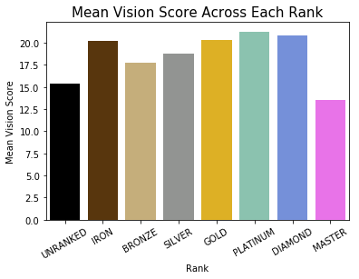

```python
sns.barplot(x = list(rank_dict.keys()), y=list(rank_dict.values()), palette=new_palette)
plt.xlabel('Rank', fontsize=10)
plt.ylabel('Mean Vision Score', fontsize=10)
plt.title('Mean Vision Score Across Each Rank', fontsize=15)
plt.xticks(rotation=30)
plt.show()
```

For now, we can ignore the value for master rank since we simply do not have enough data (2 out of 10000 in the sample) about it to make prediction.

#### How about gold?

Gold is the in-match currency that allows you to buy items in a single match. You can earn gold through killing opponents or assisting allies with kills, and killing minions in lane and monsters in the jungle. Often times, players [compared](http://forums.na.leagueoflegends.com/board/showthread.php?t=4027084) their gold earned per minute in the early game against professional players to evaluate how well they are doing in the match. Is it accurate to evaluate effectiveness based on gold earned per minute? Let's find out.

We will try to measure gold earned per minute across the whole match, not just early game.

```python
gold_match = matches
gold_match['gameDuration'] /= 60
gold_match['goldEarned'] /= gold_match['gameDuration'] # Gold earned per minute
gold_match = gold_match.drop(rankgroup.get_group('MASTER').index)
```

```python
goldgroup = gold_match.groupby('tier')
rank = ['UNRANKED', 'IRON', 'BRONZE', 'SILVER', 'GOLD', 'PLATINUM', 'DIAMOND']
gold_dict = {r: None for r in rank}

for g in goldgroup.groups:
    gold_dict[g] = goldgroup.get_group(g)['goldEarned'].mean()
goldgroup.describe()['goldEarned']
```

| tier | count | mean | std | min | 25% | 50% | 75% | max |
| --- | --- | --- | --- | --- | --- | --- | --- | --- |
| BRONZE | 1511.0 | 336.798722 | 80.035155 | 139.742574 | 280.441363 | 325.483686 | 387.806653 | 657.200287 |
| DIAMOND | 262.0 | 387.651617 | 96.985277 | 134.666667 | 323.730796 | 383.086361 | 452.774281 | 701.360078 |
| GOLD | 2193.0 | 371.369929 | 86.625919 | 140.063694 | 307.373068 | 364.611689 | 425.658613 | 743.022284 |
| IRON | 262.0 | 342.137407 | 86.462654 | 185.123703 | 281.660146 | 327.526547 | 387.201423 | 776.733021 |
| PLATINUM | 952.0 | 378.630059 | 89.267551 | 170.018484 | 311.986212 | 375.355792 | 432.611465 | 695.232087 |
| SILVER | 2771.0 | 352.724947 | 83.604249 | 138.457752 | 291.073911 | 345.085131 | 404.512286 | 703.489933 |
| UNRANKED | 2047.0 | 325.431980 | 83.154664 | 135.875706 | 265.242478 | 315.815135 | 376.690616 | 660.689655 |

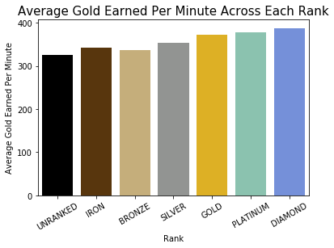

```python
sns.barplot(x = list(gold_dict.keys()), y = list(gold_dict.values()), palette=new_palette)
plt.xlabel('Rank', fontsize=10)
plt.ylabel('Average Gold Earned Per Minute', fontsize=10)
plt.title('Average Gold Earned Per Minute Across Each Rank', fontsize=15)
plt.xticks(rotation=30)
plt.yticks(np.arange(0, 500, 100))
plt.show()
```

Gold earned per minute allows you to understand your performance since gold is earned through kills and assists through opponents and monsters. It seems like it is true that higher rank players have a higher gold earned per minute measure. A higher gold earned per miniute could also imply that the player has more actions in the game to acquire more gold, leading to better performance.

Now, let's see the current patch and it's affect on champion win rates in our dataset.

```python
# Convert championId into their respective champion names
# You can find the complete json file at http://ddragon.leagueoflegends.com/cdn/9.24.2/data/en_US/champion.json
def get_championId_list(lang='en_US', version='9.24.2'):
    champ_request = requests.get("http://ddragon.leagueoflegends.com/cdn/{}/data/{}/champion.json".format(version, lang))
    if champ_request.status_code == 404:
        raise Exception("Failed to grab champion list. Ensure language and version are correct.")
    champs = champ_request.json()['data']
    champ_dict = {}
    for champ in champs:
        champ_dict[champs[champ]['key']] = champs[champ]['id']
    return champ_dict
champ_dict = get_championId_list()
```

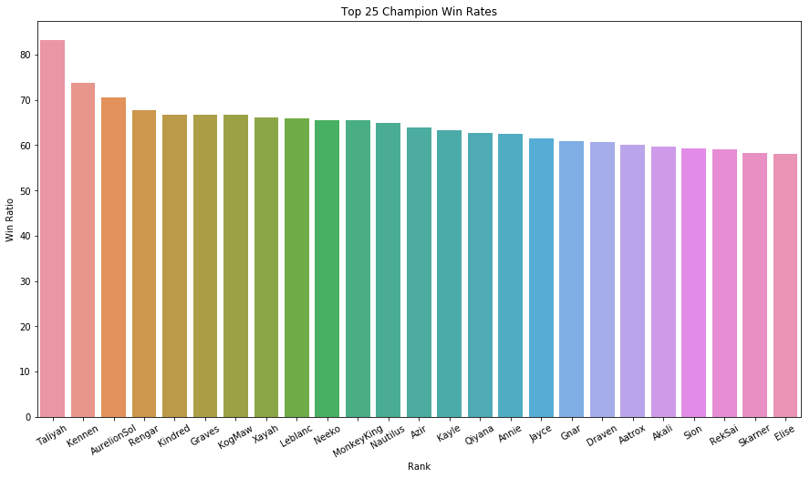

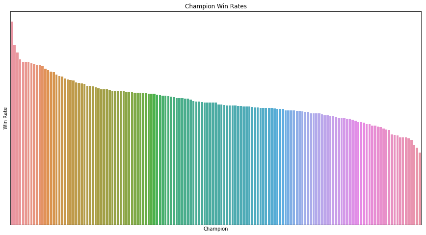

```python
champ_matches = matches.copy()
champgroup = champ_matches.groupby(['championId'])
win_rates = pd.DataFrame(columns=['Champion', 'Wins', 'Loses', 'Total Games', 'Win Rate'])
for c in champgroup.groups:
    champion = champgroup.get_group(c)
    win = champion['win'].value_counts().loc[False]
    lose = champion['win'].value_counts().loc[True]
    row = {
        'Champion': champ_dict[str(c)],
        'Wins': win,
        'Loses': lose,
        'Total Games': win + lose,
        'Win Rate': win / (win + lose) * 100
    }
    win_rates = win_rates.append(row, ignore_index=True)
sorted_win_rates = win_rates.sort_values(by=['Win Rate'], ascending=False).reset_index(drop=True)
plt.figure(figsize=(15,8))
sns.barplot(x='Champion', y='Win Rate', data=sorted_win_rates.head(25))
plt.title('Top 25 Champion Win Rates')
plt.xlabel('Rank')
plt.ylabel('Win Ratio')
plt.xticks(rotation=30)
plt.show()
plt.figure(figsize=(15,8))
plt.title('Champion Win Rates')
ax = sns.barplot(x='Champion', y='Win Rate', data=sorted_win_rates)
ax.set_yticks([])
ax.set_xticks([])
plt.show()
```

## EDA Conclusions

There's a lot of data and trends we can extract from our match data.

We only covered some common and basic ones. However, there's so much more patterns and questions we can draw out and answer.

We hope to have given you the tip of the iceberg with our graphs and we implore you to answer your own questions you may have such as

```
- Do higher ranking players die less overall? Kill more?
- In a game with friends, can higher ranking players carry lower ranking players? (High + low vs. medium + medium)
- What's the best top/mid/bottom/support/jungle champion in the current patch?
- What's the best champion to play to gain ranking at my skill level?
- How do I compare to players around my rank? Do I have a better/lower kill/ratio?
- What stats should I improve to rank up?
- Comparison of stats between each tier of rank
- Why are some champions are better than others?
```

Much much more...

# 5. Machine Learning

Since there's much to be *learned* on our data. We can develop a model to predict certain questions. What champion will make me win? What's the best team composition to win? Who is "META"?

These are all questions that we can answer from our data and we also impore you to apply different models and see what results you get!

### Sample Question: Will I win my game given my stats? What should I focus on? Kills? Objectives?

```
- Provided our stats, we can try to predict if you won your match
- Scaling down our feature set will allow us to show us how important certain stats are to victory
- This can guide a player to focus on certain parts of a match to achieve a higher chance of victory
```

```python
# One-hot encode our dataset to allow for our models to work well and efficiently
def encode(df):
    new_df = df.copy()
    vectorize_me = ['win', 'role', 'tier', 'rank', 'teamFirstBlood', 'teamFirstTowerKill', \
                       'teamFirstInhibitor', 'teamFirstBaron', 'teamFirstDragon', 'teamFirstRiftHerald']
    for v in vectorize_me:
        if v in new_df:
            values = new_df[v].unique()
            n = len(values)
            mapping = dict(zip(values, range(n)))
            new_df[v] = new_df[v].replace(mapping)
    return new_df
```

```python
full_df = matches[['win', 'gameDuration', 'role', 'tier', 'rank', 'kills', 'deaths', 'assists', 'championId', \
             'minionsKilled', 'champLevel', 'wardsPlaced', 'goldSpent', 'visionScore', 'totalDamageDealt', \
             'teamFirstBlood', 'teamFirstTowerKill', 'teamFirstInhibitor', 'teamFirstBaron', 'teamFirstDragon', \
             'teamFirstRiftHerald', 'towerKills', 'inhibitorKills', 'baronKills', 'dragonKills', 'riftHeraldKills']]
# Vectorize our data (one-hot encoding)
df = encode(full_df)
df.head()
```

|  | win | gameDuration | role | tier | rank | kills | deaths | assists | championId | minionsKilled | ... | teamFirstTowerKill | teamFirstInhibitor | teamFirstBaron | teamFirstDragon | teamFirstRiftHerald | towerKills | inhibitorKills | baronKills | dragonKills | riftHeraldKills |
| --- | --- | --- | --- | --- | --- | --- | --- | --- | --- | --- | --- | --- | --- | --- | --- | --- | --- | --- | --- | --- | --- |
| 0 | 0 | 3.983333 | 0 | 0 | 0 | 0 | 0 | 0 | 86 | 13 | ... | 0 | 0 | 0 | 0 | 0 | 0 | 0 | 0 | 0 | 0 |
| 1 | 0 | 3.983333 | 0 | 0 | 0 | 0 | 1 | 1 | 28 | 0 | ... | 0 | 0 | 0 | 0 | 0 | 0 | 0 | 0 | 0 | 0 |
| 2 | 0 | 3.983333 | 0 | 1 | 1 | 1 | 0 | 0 | 246 | 16 | ... | 0 | 0 | 0 | 0 | 0 | 0 | 0 | 0 | 0 | 0 |
| 3 | 0 | 3.983333 | 0 | 2 | 2 | 0 | 0 | 0 | 25 | 10 | ... | 0 | 0 | 0 | 0 | 0 | 0 | 0 | 0 | 0 | 0 |
| 4 | 0 | 3.983333 | 0 | 2 | 3 | 0 | 0 | 0 | 523 | 0 | ... | 0 | 0 | 0 | 0 | 0 | 0 | 0 | 0 | 0 | 0 |

5 rows × 26 columns

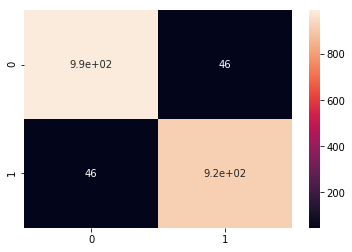

```
              precision    recall  f1-score   support

           0       0.96      0.96      0.96      1036
           1       0.95      0.95      0.95       964

   micro avg       0.95      0.95      0.95      2000
   macro avg       0.95      0.95      0.95      2000
weighted avg       0.95      0.95      0.95      2000

Cross-Validated Scores:  [0.896 0.94  0.918 0.958 0.942 0.889 0.921 0.923 0.941 0.92 ]
```

```python
X = df.drop('win', axis=1)
y = df['win']

X_train, X_test, y_train, y_test = train_test_split(X, y, test_size=.2)

rf = RandomForestClassifier()
rf.fit(X_train, y_train)
rf_pred = rf.predict(X_test)
conf_mat = confusion_matrix(y_test, rf_pred)
sns.heatmap(conf_mat, annot=True)
plt.show()
print(classification_report(y_test, rf_pred))
print("Cross-Validated Scores: ",cross_val_score(rf, X, y, cv=10))
```

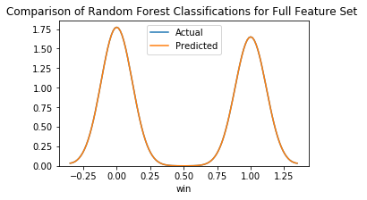

```python
f, ax = plt.subplots(figsize=(5, 3))
plt.title('Comparison of Random Forest Classifications for Full Feature Set ')
sns.distplot(y_test, hist=False, label="Actual", ax=ax)
sns.distplot(rf_pred, hist=False, label="Predicted", ax=ax)
plt.show()
```

### Analysis:

We can see that with our random forest classifier, we can acutally predict when we know all the features. Now lets test with fewer features.

The features we chose are some factors that can be easily determined to be a win

- Maybe higher KillDeathAssist (KDA) Ratio == win?

```python
full_df = matches[['win', 'gameDuration', 'role', 'tier', 'rank', 'kills', 'deaths', 'assists', 'championId', \
                   'wardsPlaced', 'goldSpent', 'visionScore', 'teamFirstBlood', 'teamFirstTowerKill', \
                   'teamFirstInhibitor', 'teamFirstBaron', 'teamFirstDragon', 'teamFirstRiftHerald']]
# Vectorize our data (one-hot encoding)
df = encode(full_df)
df.head()
```

|  | win | gameDuration | role | tier | rank | kills | deaths | assists | championId | wardsPlaced | goldSpent | visionScore | teamFirstBlood | teamFirstTowerKill | teamFirstInhibitor | teamFirstBaron | teamFirstDragon | teamFirstRiftHerald |
| --- | --- | --- | --- | --- | --- | --- | --- | --- | --- | --- | --- | --- | --- | --- | --- | --- | --- | --- |
| 0 | 0 | 3.983333 | 0 | 0 | 0 | 0 | 0 | 0 | 86 | 1 | 500 | 0 | 0 | 0 | 0 | 0 | 0 | 0 |
| 1 | 0 | 3.983333 | 0 | 0 | 0 | 0 | 1 | 1 | 28 | 0 | 1150 | 0 | 0 | 0 | 0 | 0 | 0 | 0 |
| 2 | 0 | 3.983333 | 0 | 1 | 1 | 1 | 0 | 0 | 246 | 0 | 500 | 0 | 0 | 0 | 0 | 0 | 0 | 0 |
| 3 | 0 | 3.983333 | 0 | 2 | 2 | 0 | 0 | 0 | 25 | 1 | 500 | 1 | 0 | 0 | 0 | 0 | 0 | 0 |
| 4 | 0 | 3.983333 | 0 | 2 | 3 | 0 | 0 | 0 | 523 | 0 | 0 | 0 | 0 | 0 | 0 | 0 | 0 | 0 |

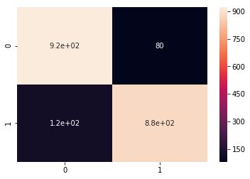

```
              precision    recall  f1-score   support

           0       0.88      0.92      0.90      1001
           1       0.92      0.88      0.90       999

   micro avg       0.90      0.90      0.90      2000
   macro avg       0.90      0.90      0.90      2000
weighted avg       0.90      0.90      0.90      2000

Cross-Validated Scores:  [0.861 0.894 0.853 0.891 0.911 0.848 0.885 0.857 0.903 0.859]
```

```python
X = df.drop('win', axis=1)
y = df['win']

X_train, X_test, y_train, y_test = train_test_split(X, y, test_size=.2)

rf = RandomForestClassifier()
rf.fit(X_train, y_train)
rf_pred = rf.predict(X_test)
conf_mat = confusion_matrix(y_test, rf_pred)
sns.heatmap(conf_mat, annot=True)
plt.show()
print(classification_report(y_test, rf_pred))
print("Cross-Validated Scores: ",cross_val_score(rf, X, y, cv=10))
```

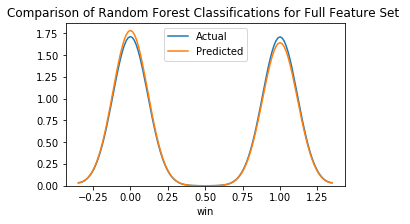

```python
f, ax = plt.subplots(figsize=(5, 3))
plt.title('Comparison of Random Forest Classifications for Full Feature Set ')
sns.distplot(y_test, hist=False, label="Actual", ax=ax)
sns.distplot(rf_pred, hist=False, label="Predicted", ax=ax)
plt.show()
```

### Analysis:

As expected, the model is accuratly predicting a win.

Now lets cut out KDA, gold spent. These features left can be incorporated by either team evenly, maybe now the model can learn on the championId heavier.

```python
full_df = matches[['win', 'gameDuration', 'championId', 'wardsPlaced', 'visionScore', 'teamFirstBlood', \
                   'teamFirstTowerKill', 'teamFirstInhibitor', 'teamFirstBaron', 'teamFirstDragon', 'teamFirstRiftHerald']]
# Vectorize our data (one-hot encoding)
df = encode(full_df)
df.head()
```

|  | win | gameDuration | championId | wardsPlaced | visionScore | teamFirstBlood | teamFirstTowerKill | teamFirstInhibitor | teamFirstBaron | teamFirstDragon | teamFirstRiftHerald |
| --- | --- | --- | --- | --- | --- | --- | --- | --- | --- | --- | --- |
| 0 | 0 | 3.983333 | 86 | 1 | 0 | 0 | 0 | 0 | 0 | 0 | 0 |
| 1 | 0 | 3.983333 | 28 | 0 | 0 | 0 | 0 | 0 | 0 | 0 | 0 |
| 2 | 0 | 3.983333 | 246 | 0 | 0 | 0 | 0 | 0 | 0 | 0 | 0 |
| 3 | 0 | 3.983333 | 25 | 1 | 1 | 0 | 0 | 0 | 0 | 0 | 0 |
| 4 | 0 | 3.983333 | 523 | 0 | 0 | 0 | 0 | 0 | 0 | 0 | 0 |

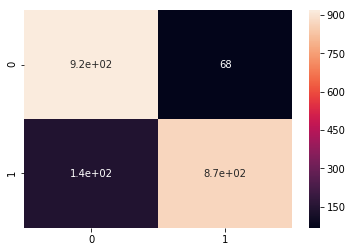

```
              precision    recall  f1-score   support

           0       0.86      0.93      0.90       986
           1       0.93      0.86      0.89      1014

   micro avg       0.89      0.89      0.89      2000
   macro avg       0.90      0.89      0.89      2000
weighted avg       0.90      0.89      0.89      2000

Cross-Validated Scores:  [0.847 0.842 0.836 0.867 0.896 0.805 0.852 0.836 0.883 0.821]
```

```python
X = df.drop('win', axis=1)
y = df['win']

X_train, X_test, y_train, y_test = train_test_split(X, y, test_size=.2)

rf = RandomForestClassifier()
rf.fit(X_train, y_train)
rf_pred = rf.predict(X_test)
conf_mat = confusion_matrix(y_test, rf_pred)
sns.heatmap(conf_mat, annot=True)
plt.show()
print(classification_report(y_test, rf_pred))
print("Cross-Validated Scores: ",cross_val_score(rf, X, y, cv=10))
```

### Analysis:

Even without kills, deaths, assists, and goldSpent, the model can accuratly predict maybe on vision score, the championId.

Now... let's remove everything except for the champion you play and your team's firsts objective kills.

```python
full_df = matches[['win', 'championId', 'teamFirstBlood', 'teamFirstTowerKill', \
                   'teamFirstInhibitor', 'teamFirstBaron', 'teamFirstDragon', 'teamFirstRiftHerald']]
# Vectorize our data (one-hot encoding)
df = encode(full_df)
df.head()
```

|  | win | championId | teamFirstBlood | teamFirstTowerKill | teamFirstInhibitor | teamFirstBaron | teamFirstDragon | teamFirstRiftHerald |
| --- | --- | --- | --- | --- | --- | --- | --- | --- |
| 0 | 0 | 86 | 0 | 0 | 0 | 0 | 0 | 0 |
| 1 | 0 | 28 | 0 | 0 | 0 | 0 | 0 | 0 |
| 2 | 0 | 246 | 0 | 0 | 0 | 0 | 0 | 0 |
| 3 | 0 | 25 | 0 | 0 | 0 | 0 | 0 | 0 |
| 4 | 0 | 523 | 0 | 0 | 0 | 0 | 0 | 0 |

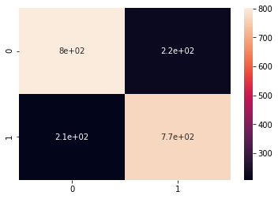

```
              precision    recall  f1-score   support

           0       0.79      0.78      0.79      1023
           1       0.78      0.79      0.78       977

   micro avg       0.79      0.79      0.79      2000
   macro avg       0.79      0.79      0.79      2000
weighted avg       0.79      0.79      0.79      2000

Cross-Validated Scores:  [0.765 0.783 0.779 0.811 0.799 0.766 0.797 0.767 0.801 0.761]
```

```python
X = df.drop('win', axis=1)
y = df['win']

X_train, X_test, y_train, y_test = train_test_split(X, y, test_size=.2)

rf = RandomForestClassifier()
rf.fit(X_train, y_train)
rf_pred = rf.predict(X_test)
conf_mat = confusion_matrix(y_test, rf_pred)
sns.heatmap(conf_mat, annot=True)
plt.show()
print(classification_report(y_test, rf_pred))
print("Cross-Validated Scores: ",cross_val_score(rf, X, y, cv=10))
```

### Analysis:

Based entirely on your champion and your team's first objective kills, we can see that these features are extremly important for winning a game.

Now lets's see if this team game called League of Legends can be won entirely on your champion choice...

```python
full_df = matches[['win', 'championId']]
# Vectorize our data (one-hot encoding)
df = encode(full_df)
df.head()
```

|  | win | championId |
| --- | --- | --- |
| 0 | 0 | 86 |
| 1 | 0 | 28 |
| 2 | 0 | 246 |
| 3 | 0 | 25 |
| 4 | 0 | 523 |

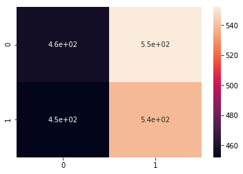

```
              precision    recall  f1-score   support

           0       0.50      0.45      0.48      1009
           1       0.49      0.54      0.52       991

   micro avg       0.50      0.50      0.50      2000
   macro avg       0.50      0.50      0.50      2000
weighted avg       0.50      0.50      0.50      2000

Cross-Validated Scores:  [0.511 0.513 0.522 0.503 0.522 0.486 0.517 0.498 0.528 0.489]
```

```python
X = df.drop('win', axis=1)
y = df['win']

X_train, X_test, y_train, y_test = train_test_split(X, y, test_size=.2)

rf = RandomForestClassifier()
rf.fit(X_train, y_train)
rf_pred = rf.predict(X_test)
conf_mat = confusion_matrix(y_test, rf_pred)
sns.heatmap(conf_mat, annot=True)
plt.show()
print(classification_report(y_test, rf_pred))
print("Cross-Validated Scores: ",cross_val_score(rf, X, y, cv=10))
```

### Last Analysis:

As we can see, a team game heavily relies on your team working together to secure key objectives.

It can be said that that games cannot be soley predicted upon choosing a champion from our results.

Winning = Team efforts. Who would have thought?

# 6. Takeaway...

Riot Games has provided us with available and comprehensive League of Legends data. We hope that this tutorial shows a simple implementation of their API and use-cases of their data in data science.

As mentioned before, we hope that you see how the API can be used and we hope that anyone interested can construct even more elaborate models and datasets to capture all the questions we posed in the EDA Conclusions section and more!

*Thanks for reading!*

[figure not shown]

```
                                                                                        - Worlds 2019
```